# Problem Set 8

Westley Cook

4/15/2020

## Question 1: Exploratory Data Analysis

### 1A) Summary Statistics

Data summary

| Name | Piped data |
| --- | --- |
| Number of rows | 4929 |
| Number of columns | 2 |
| _______________________ |  |
| Column type frequency: |  |
| numeric | 2 |
| ________________________ |  |
| Group variables | None |

**Variable type: numeric**

| skim_variable | n_missing | complete_rate | mean | sd | p0 | p25 | p50 | p75 | p100 | hist |
| --- | --- | --- | --- | --- | --- | --- | --- | --- | --- | --- |
| total_tweets | 0 | 1 | 19.73 | 28.41 | 0.0 | 0.0 | 0 | 41 | 109 | ▇▁▂▁▁ |
| approve | 0 | 1 | 41.36 | 4.08 | 23.9 | 38.1 | 41 | 44 | 59 | ▁▂▇▃▁ |

### 1B) Bivariate Correlations

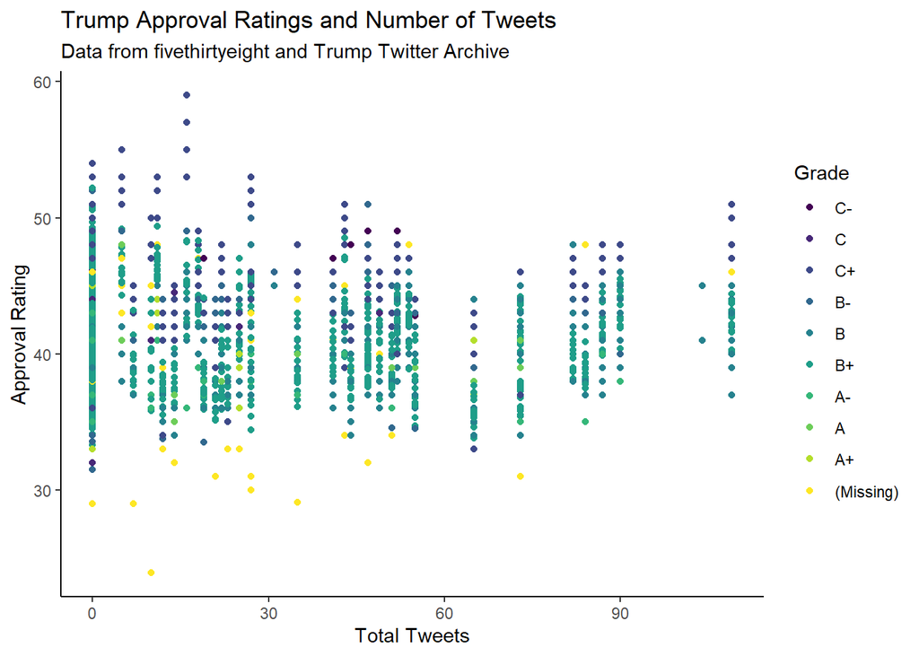

The correlation coefficient between the approval rating and the number of tweets is **-0.026**. There does NOT seem to be a strong relationship between tweet activity and approval ratings.

## Question 2: Multivariate Regression

### 2A) Using lm()

Effect of Number of Tweets and Poll Quality on Reported Approval Rating

Data from fivethirtyeight and Trump Tweet Archive

| Variable | Estimate | Lower Bound | Upper Bound |
| --- | --- | --- | --- |
| (Intercept) | 41.603 | 41.462 | 41.7443 |
| total_tweets | -0.004 | -0.008 | -0.0003 |
| high_q | -2.347 | -2.792 | -1.9021 |

### 2B) Interpreting Results

The estimated average treatment effect of high_q is -2.347, which means that taking into account all other variables in the model, a high-quality poll is expected to produce an approval rating roughly 2.3 points *lower* than a low-quality poll.

The frequentist interpretation of the confidence interval is that 95% of the time, using the process we used will generate an interval containing the true value of the average treatment effect of each variable on approval rating. The Bayesian interpretation is that there is a 95% chance that the interval we created here contains the true value of the average treatment effect.

### 2C) Interaction Variables

Effect of Number of Tweets and Poll Quality on Reported Approval Rating

Data from fivethirtyeight and Trump Tweet Archive

| Variable | Estimate | Lower Bound | Upper Bound |
| --- | --- | --- | --- |
| (Intercept) | 41.629 | 41.487 | 41.772 |
| total_tweets | -0.006 | -0.010 | -0.001 |
| high_q | -2.701 | -3.228 | -2.175 |
| total_tweets:high_q | 0.021 | 0.004 | 0.037 |

### 2D) Estimating Fitted Values

This model would predict that for Monmouth University’s A+ rated poll during a week in which President Trump tweeted 84 times, the approval rating would be as follows:

Predicted approval rating = Intercept estimate - high_q + (total_tweets + total_tweets:high_q) * number of tweets

Predicted approval rating = 41.629 - 2.701 + (-0.006 + 0.021) * 84 = **40.188**

Calculating the predicted value using R’s predict() function, we get almost exactly the same result (discrepancy due to roundoff error):

```r
# Naming the interaction model

interaction_model <- lm(approve ~ total_tweets * high_q,
                        data = new_approval_tweets)

# Predicting the model's result given a high-quality poll and 84 tweets

predict(interaction_model, tibble(total_tweets = 84, high_q = 1))
```

```
##        1
## 40.18311
```

### 2E) Multiple Regression and the Rubin Causal Model

Taking into account all other variables in the model, the coefficient for total_tweets would be the average expected treatment effect for each unit of total_tweets (presumably one tweet) when democrat = 0. In other words, it’s the slope of the line when democrat = 0 (which presumably means the respondent was Republican).

The coefficient for democrat would be the *offset* from the baseline intercept when democrat = 1; the baseline intercept is the expected approval rating if total_tweets = 0 and democrat = 0 (in other words, the expected Republican approval rating if the president doesn’t tweet). So the expected approval rating when democrat = 1 and total_tweets = 0 (or in other words, the expected approval rating for a Democrat when the president doesn’t tweet) would be the baseline intercept *plus* this coefficient.

The coefficient for total_tweets:democrat would be the *offset* from the coefficient for total_tweets when democrat = 1. So the slope of the line when democrat = 1 (presumably meaning the respondent is a Democrat) would be the coefficient for total_tweets *plus* this coefficient.

This seems to be an explanatory model, because it’s attempting to isolate the magnitude of the effect of each variable (total_tweets, democrat, and total_tweets:democrat). If it were a predictive model, it would care more about just getting an accurate prediction than it would about the respective magnitudes of each variable in the model.

## Question 3: Many Regressions

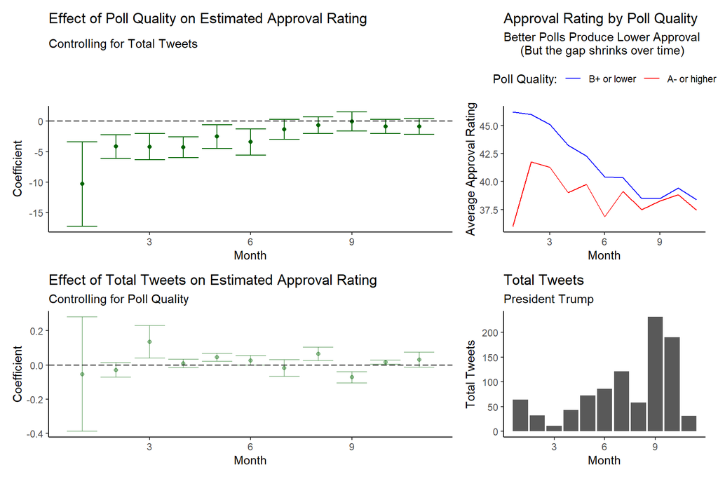

##### Worked with:

None (but Wyatt Hurt’s tip on Piazza about setting fig.width and fig.height in the final code chunk helped me format a nice-looking four-plot display!)